# Variable Importance in mysuperlearner

# Variable Importance Module

The variable importance module provides comprehensive tools for evaluating feature importance in fitted SuperLearner models.

## Setup

```python
import numpy as np
import pandas as pd
import matplotlib.pyplot as plt
from sklearn.linear_model import LogisticRegression
from sklearn.ensemble import RandomForestClassifier
from sklearn.tree import DecisionTreeClassifier

from mysuperlearner import SuperLearner, compute_variable_importance

# Set random seed for reproducibility
np.random.seed(42)
```

## Create Synthetic Data

Let’s create a dataset with known feature importance to demonstrate the methods.

```python
# Create synthetic dataset with 10 features
n_samples = 200
n_features = 10

# Generate features
X_data = {}
for i in range(n_features):
    X_data[f'feature_{i}'] = np.random.randn(n_samples)

X = pd.DataFrame(X_data)

# Create target with known feature importance:
# feature_0 and feature_1 are highly important
# feature_2 and feature_3 are moderately important
# remaining features are noise
y = (
    2.0 * X['feature_0'] +
    1.5 * X['feature_1'] +
    0.5 * X['feature_2'] +
    0.3 * X['feature_3'] +
    np.random.randn(n_samples) > 0
).astype(int)

print(f"Dataset shape: {X.shape}")
print(f"Target distribution: {np.bincount(y)}")
print(f"\nTrue importance ranking:")
print("1. feature_0 (coefficient: 2.0)")
print("2. feature_1 (coefficient: 1.5)")
print("3. feature_2 (coefficient: 0.5)")
print("4. feature_3 (coefficient: 0.3)")
print("5-10. feature_4-9 (noise)")
```

```
Dataset shape: (200, 10)
Target distribution: [ 95 105]

True importance ranking:
1. feature_0 (coefficient: 2.0)
2. feature_1 (coefficient: 1.5)
3. feature_2 (coefficient: 0.5)
4. feature_3 (coefficient: 0.3)
5-10. feature_4-9 (noise)
```

## Fit SuperLearner

```python
# Create base learners
learners = [
    ('logistic', LogisticRegression(max_iter=500)),
    ('rf', RandomForestClassifier(n_estimators=50, max_depth=5, random_state=42)),
    ('tree', DecisionTreeClassifier(max_depth=3, random_state=42))
]

# Fit SuperLearner
# IMPORTANT: Set store_X=True to enable variable importance
sl = SuperLearner(
    learners=learners,
    method='nnloglik',
    cv=5,
    random_state=42
)

sl.fit(X, y, store_X=True)

print("SuperLearner fitted successfully!")
print(f"\nMeta-learner weights:")
for name, weight in zip([name for name, _ in learners], sl.meta_weights_):
    print(f"  {name}: {weight:.4f}")
```

```
SuperLearner fitted successfully!

Meta-learner weights:
  logistic: 0.9191
  rf: 0.0735
  tree: 0.0074
```

## Method 1: Permutation Feature Importance

Permutation importance measures the decrease in model performance when a feature’s values are randomly shuffled.

```python
print("Computing Permutation Feature Importance...")
results_perm = compute_variable_importance(
    sl,
    method='permutation',
    n_repeats=5,  # Repeat permutations for variance estimation
    metric='auc',
    random_state=42,
    n_jobs=1,  # Set to -1 to use all CPUs for parallel execution
    verbose=False
)

print("\nTop 5 most important features:")
print(results_perm.summary(top_n=5))
```

```
Computing Permutation Feature Importance...

Top 5 most important features:
     feature       method  importance  importance_se  importance_ci_lower  \
0  feature_0  permutation    0.233784       0.010139             0.212859
1  feature_1  permutation    0.073885       0.007819             0.057747
2  feature_2  permutation    0.010326       0.002665             0.004825
9  feature_9  permutation    0.002105       0.002024            -0.002072
6  feature_6  permutation    0.001404       0.001366            -0.001415

   importance_ci_upper  importance_normalized  rank
0             0.254710               1.000000     1
1             0.090023               0.323866     2
2             0.015827               0.055108     3
9             0.006283               0.020348     4
6             0.004222               0.017380     5
```

### Visualize Permutation Importance

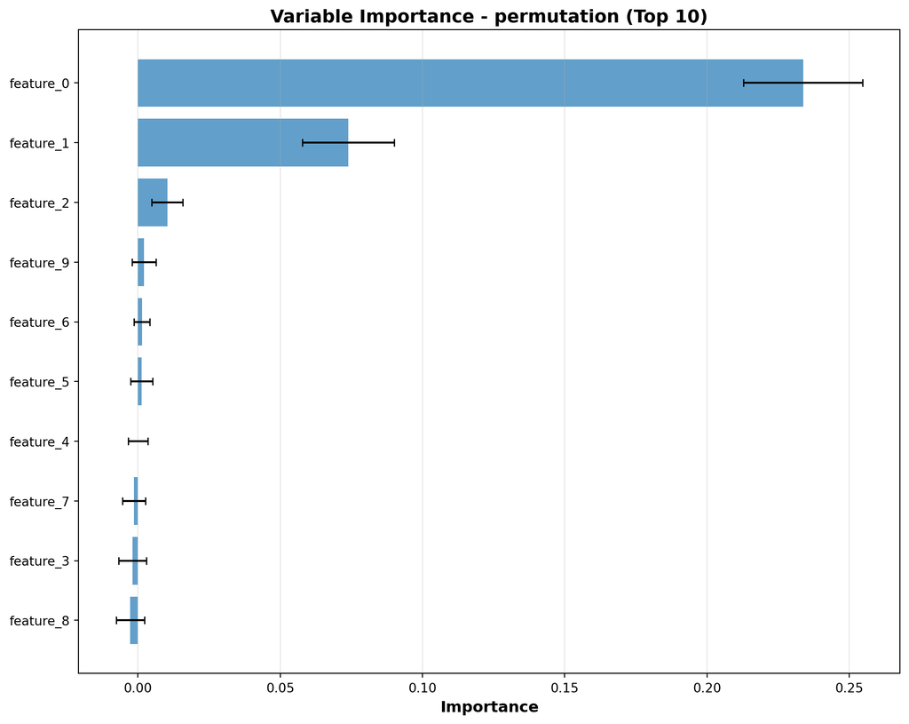

Permutation Feature Importance with 95% Confidence Intervals

```python
fig, ax = results_perm.plot_importance_bar(top_n=10)
plt.tight_layout()
plt.show()
```

## Method 2: Drop-Column Importance

Drop-column importance completely removes a feature and re-trains the model.

```python
print("Computing Drop-Column Feature Importance...")
results_drop = compute_variable_importance(
    sl,
    method='drop_column',
    metric='auc',
    verbose=False
)

print("\nTop 5 most important features:")
print(results_drop.summary(top_n=5))
```

```
Computing Drop-Column Feature Importance...

Top 5 most important features:
     feature       method  importance  importance_se  importance_ci_lower  \
0  feature_0  drop_column    0.228070       0.022916             0.164446
1  feature_1  drop_column    0.068170       0.018373             0.017159
2  feature_2  drop_column    0.007519       0.005317            -0.007242
9  feature_9  drop_column    0.003008       0.001461            -0.001050
6  feature_6  drop_column   -0.000501       0.002156            -0.006487

   importance_ci_upper  importance_normalized  rank
0             0.291694               1.000000     1
1             0.119182               0.306522     2
2             0.022280               0.043478     3
9             0.007065               0.023913     4
6             0.005485               0.008696     5
```

## Method 3: Grouped Feature Importance

Grouped importance uses hierarchical clustering to group correlated features and permutes entire groups.

```python
print("Computing Grouped Feature Importance...")
results_grouped = compute_variable_importance(
    sl,
    method='grouped',
    grouped_threshold=0.7,  # Cluster features with |correlation| > 0.7
    n_repeats=5,
    metric='auc',
    random_state=42,
    verbose=False
)

print("\nFeature clusters:")
clusters = results_grouped.cluster_info.groupby('group_id')['feature'].apply(list)
for group_id, features in clusters.items():
    print(f"  Group {group_id}: {', '.join(features)}")

print("\nTop 5 most important groups:")
print(results_grouped.summary(top_n=5))
```

```
Computing Grouped Feature Importance...

Feature clusters:
  Group 1: feature_7
  Group 2: feature_9
  Group 3: feature_3
  Group 4: feature_4
  Group 5: feature_1
  Group 6: feature_2
  Group 7: feature_6
  Group 8: feature_0
  Group 9: feature_8
  Group 10: feature_5

Top 5 most important groups:
    feature   method  importance  importance_se  importance_ci_lower  \
8   group_8  grouped    0.234185       0.009393             0.214799
5   group_5  grouped    0.072381       0.007580             0.056736
2   group_2  grouped    0.006917       0.002191             0.002395
6   group_6  grouped    0.006316       0.002858             0.000417
1  group_10  grouped    0.000802       0.001661            -0.002626

   importance_ci_upper  importance_normalized  rank
8             0.253572               1.000000     1
5             0.088026               0.315522     2
2             0.011439               0.038592     3
6             0.012214               0.036047     4
1             0.004230               0.012723     5
```

## Compare Multiple Methods

We can compute multiple importance methods simultaneously and compare their results.

```python
print("Computing All Methods for Comparison...")
results_all = compute_variable_importance(
    sl,
    method=['permutation', 'drop_column'],
    n_repeats=5,
    metric='auc',
    random_state=42,
    verbose=False
)

print("\nComparison of feature rankings across methods:")
comparison = results_all.compare_methods()
print(comparison)
```

```
Computing All Methods for Comparison...

Comparison of feature rankings across methods:
method     drop_column  permutation
feature
feature_0          1.0          1.0
feature_1          2.0          2.0
feature_2          3.0          3.0
feature_9          4.0          4.0
feature_6          5.0          5.0
feature_7          6.0          8.0
feature_5          6.0          6.0
feature_3          7.0          9.0
feature_4          8.0          7.0
feature_8          8.0         10.0
```

### Heatmap Comparison

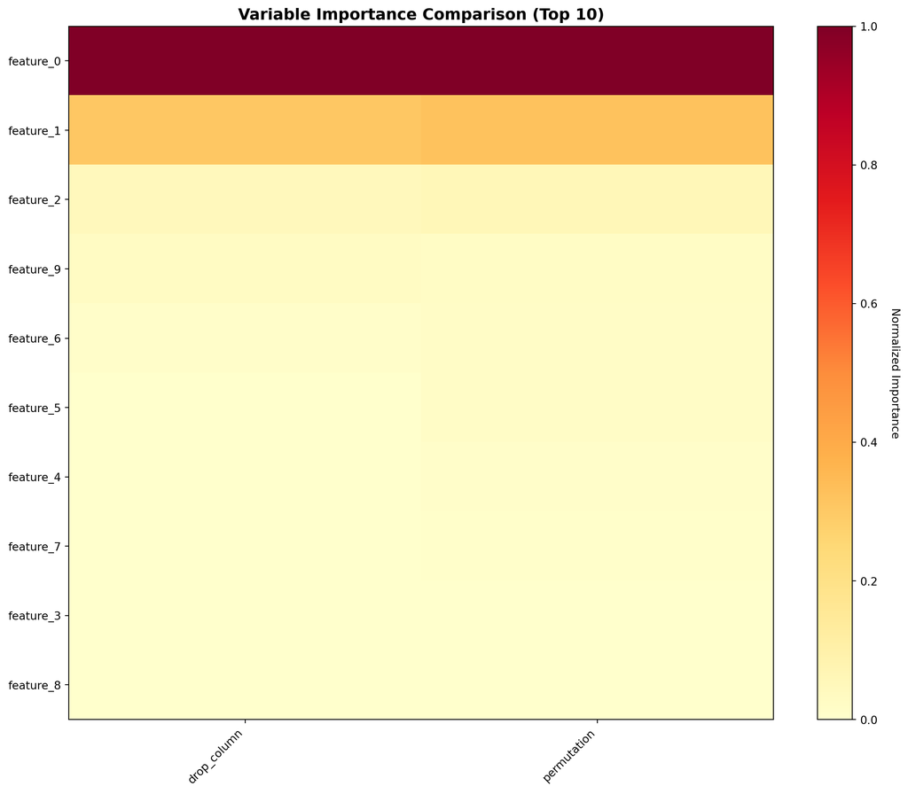

Feature Importance Comparison Across Methods

```python
fig, ax = results_all.plot_importance_heatmap(top_n=10)
plt.tight_layout()
plt.show()
```

## Access Raw Results

The results object contains both aggregated and fold-level data.

```python
print("Aggregated importance (first 5 features):")
print(results_perm.importance_df.head())

print("\n\nRaw fold-level importance (first 10 rows):")
print(results_perm.raw_importance_df.head(10))
```

```
Aggregated importance (first 5 features):
     feature       method    importance  importance_se  importance_ci_lower  \
0  feature_0  permutation  2.337845e-01       0.010139             0.212859
1  feature_1  permutation  7.388471e-02       0.007819             0.057747
2  feature_2  permutation  1.032581e-02       0.002665             0.004825
3  feature_3  permutation -1.904762e-03       0.002330            -0.006714
4  feature_4  permutation  1.776357e-17       0.001650            -0.003405

   importance_ci_upper  importance_normalized  rank
0             0.254710               1.000000     1
1             0.090023               0.323866     2
2             0.015827               0.055108     3
3             0.002904               0.003391     9
4             0.003405               0.011446     7


Raw fold-level importance (first 10 rows):
     feature  fold  repeat  importance  baseline_score  modified_score
0  feature_0     0       0    0.203008        0.917293        0.714286
1  feature_0     1       0    0.290727        0.939850        0.649123
2  feature_0     2       0    0.245614        0.874687        0.629073
3  feature_0     3       0    0.290727        0.962406        0.671679
4  feature_0     4       0    0.157895        0.909774        0.751880
5  feature_0     0       1    0.182957        0.917293        0.734336
6  feature_0     1       1    0.288221        0.939850        0.651629
7  feature_0     2       1    0.248120        0.874687        0.626566
8  feature_0     3       1    0.285714        0.962406        0.676692
9  feature_0     4       1    0.177945        0.909774        0.731830
```

## Programmatic Access

```python
# Get top N features as a list
top_features = results_perm.get_top_features(n=5)
print(f"Top 5 features: {top_features}")

# Access configuration
print(f"\nAnalysis configuration:")
for key, value in results_perm.config.items():
    print(f"  {key}: {value}")
```

```
Top 5 features: ['feature_0', 'feature_1', 'feature_2', 'feature_9', 'feature_6']

Analysis configuration:
  methods: ['permutation']
  metric: auc
  n_repeats: 5
  grouped_threshold: 0.7
  random_state: 42
  n_jobs: 1
```

## API Reference

### Main Function

```python
compute_variable_importance(
    sl,                      # Fitted SuperLearner
    method='permutation',    # str or list: 'permutation', 'drop_column', 'grouped', 'shap'
    X=None,                  # Feature matrix (uses sl.X_ if None)
    y=None,                  # Target (uses sl.y_ if None)
    metric='auc',            # 'auc', 'accuracy', 'logloss', or callable
    n_repeats=5,             # Permutation repeats for variance estimation
    grouped_threshold=0.7,   # Correlation threshold for grouped PFI
    random_state=None,       # Random seed
    verbose=False,           # Print progress
    n_jobs=1                 # Parallel jobs: -1 uses all CPUs, 1 is sequential
)
```

### VariableImportanceResults Methods

- `summary(top_n=10, method=None)` - Top N features
- `get_top_features(n=10, method=None)` - List of feature names
- `compare_methods()` - Compare rankings across methods
- `plot_importance_bar(top_n=20, method=None)` - Bar plot with CIs
- `plot_importance_heatmap(top_n=30)` - Cross-method heatmap
- `plot_grouped_clusters()` - Cluster visualization
- `plot_shap_summary(X=None, plot_type='bar')` - SHAP plot (if method=‘shap’)

## Performance Considerations

**Computational Cost:**

- **Permutation**: O(n_features × n_folds × n_repeats × training_time)
- **Drop-column**: O(n_features × n_folds × training_time)
- **Grouped**: O(n_groups × n_folds × n_repeats × training_time) - faster when n_groups << n_features
- **SHAP**: O(n_samples × n_features × n_background) - can be expensive

**Parallel Execution:**

Variable importance computation supports parallel execution via the `n_jobs` parameter:

- `n_jobs=1` (default): Sequential execution
- `n_jobs=2-8`: Use specific number of CPUs (recommended for medium datasets)
- `n_jobs=-1`: Use all available CPUs (recommended for large datasets)

**Performance Scaling:** - Small datasets (<10 features): 1-2x speedup with n_jobs=2 - Medium datasets (10-50 features): 5-10x speedup with n_jobs=-1 - Large datasets (50+ features): 10-25x speedup with n_jobs=-1

**Memory:**

- Setting `store_X=True` doubles SuperLearner memory usage
- Parallel execution: Each worker creates a copy of data (total_memory ≈ n_jobs × dataset_size)
- Alternative: Keep `store_X=False` and pass X explicitly

**Example without storing X:**

```python
# Fit without store_X to save memory
sl_memory_efficient = SuperLearner(learners=learners, method='nnloglik', cv=5)
sl_memory_efficient.fit(X, y, store_X=False)

# Provide X explicitly for importance
results_explicit = compute_variable_importance(
    sl_memory_efficient,
    X=X,  # Pass explicitly
    y=y,
    method='permutation',
    n_repeats=3,
    verbose=False
)

print("Top 3 features (memory-efficient approach):")
print(results_explicit.summary(top_n=3))
```

```
Top 3 features (memory-efficient approach):
     feature       method  importance  importance_se  importance_ci_lower  \
0  feature_0  permutation    0.231078       0.012422             0.204436
1  feature_1  permutation    0.061487       0.009685             0.040715
8  feature_8  permutation    0.004177       0.002502            -0.001190

   importance_ci_upper  importance_normalized  rank
0             0.257719               1.000000     1
1             0.082259               0.276550     2
8             0.009544               0.032074     3
```

## Output DataFrame Structure

### Aggregated Results

```python
print("Columns in aggregated importance DataFrame:")
print(results_perm.importance_df.columns.tolist())
print("\nExample row:")
print(results_perm.importance_df.iloc[0])
```

```
Columns in aggregated importance DataFrame:
['feature', 'method', 'importance', 'importance_se', 'importance_ci_lower', 'importance_ci_upper', 'importance_normalized', 'rank']

Example row:
feature                    feature_0
method                   permutation
importance                  0.233784
importance_se               0.010139
importance_ci_lower         0.212859
importance_ci_upper          0.25471
importance_normalized            1.0
rank                               1
Name: 0, dtype: object
```

### Raw Results

```python
print("\nColumns in raw importance DataFrame:")
print(results_perm.raw_importance_df.columns.tolist())
print("\nExample row:")
print(results_perm.raw_importance_df.iloc[0])
```

```
Columns in raw importance DataFrame:
['feature', 'fold', 'repeat', 'importance', 'baseline_score', 'modified_score']

Example row:
feature           feature_0
fold                      0
repeat                    0
importance         0.203008
baseline_score     0.917293
modified_score     0.714286
Name: 0, dtype: object
```

## Custom Metrics

You can provide custom metric functions:

```python
from sklearn.metrics import precision_score

def custom_precision(y_true, y_pred):
    """Custom metric: precision at 0.5 threshold"""
    y_pred_binary = (y_pred > 0.5).astype(int)
    return precision_score(y_true, y_pred_binary)

results_custom = compute_variable_importance(
    sl,
    method='permutation',
    metric=custom_precision,
    n_repeats=3,
    verbose=False
)

print("Top 5 features by custom precision metric:")
print(results_custom.summary(top_n=5))
```

```
Top 5 features by custom precision metric:
     feature       method  importance  importance_se  importance_ci_lower  \
0  feature_0  permutation    0.190208       0.022903             0.141085
1  feature_1  permutation    0.069191       0.018939             0.028572
2  feature_2  permutation    0.035511       0.010063             0.013929
9  feature_9  permutation    0.016069       0.006628             0.001853
7  feature_7  permutation    0.007886       0.007739            -0.008712

   importance_ci_upper  importance_normalized  rank
0             0.239331               1.000000     1
1             0.109810               0.369118     2
2             0.057094               0.193543     3
9             0.030286               0.092188     4
7             0.024483               0.049524     5
```

## Integration with SuperLearner Workflow

```python
# Example: Complete workflow
# 1. Fit SuperLearner
sl_workflow = SuperLearner(learners=learners, method='nnloglik', cv=5)
sl_workflow.fit(X, y, store_X=True)

print("SuperLearner fitted successfully!")

# 2. Variable importance on fitted model
importance = compute_variable_importance(
    sl_workflow,
    method='permutation',
    n_repeats=5,
    random_state=42,
    verbose=False
)

print("\nTop 3 important features:")
print(importance.summary(top_n=3))

# 3. Make predictions on new data
predictions = sl_workflow.predict_proba(X[:5])
print(f"\nPredictions for first 5 samples:")
print(predictions[:5, 1])  # Probability of class 1
```

```
SuperLearner fitted successfully!

Top 3 important features:
     feature       method  importance  importance_se  importance_ci_lower  \
0  feature_0  permutation    0.228271       0.006924             0.213980
1  feature_1  permutation    0.072581       0.006230             0.059724
2  feature_2  permutation    0.007820       0.002431             0.002802

   importance_ci_upper  importance_normalized  rank
0             0.242562               1.000000     1
1             0.085439               0.336892     2
2             0.012837               0.061059     3

Predictions for first 5 samples:
[0.75694088 0.49333845 0.97074669 0.98690472 0.09520805]
```

## Summary

The variable importance module provides:

✅ **Multiple importance methods**: Permutation, drop-column, grouped, and SHAP

✅ **Statistical rigor**: Confidence intervals, standard errors, fold-level estimates

✅ **Flexibility**: Works with fitted SuperLearner or accepts X/y explicitly

✅ **Visualization**: Built-in plotting functions with consistent styling

✅ **Memory efficiency**: Optional X storage for memory-constrained environments

For more examples, see `examples/variable_importance_example.py`.